# Practical Machine Learning - Prediction Assignment Writeup

Monday, January 25, 2016

### Background

Using devices such as Jawbone Up, Nike FuelBand, and Fitbit it is now possible to collect a large amount of data about personal activity relatively inexpensively. These type of devices are part of the quantified self movement and a group of enthusiasts who take measurements about themselves regularly to improve their health, to find patterns in their behavior, or because they are tech geeks. One thing that people regularly do is quantify how much of a particular activity they do, but they rarely quantify how well they do it. In this project, your goal will be to use data from accelerometers on the belt, forearm, arm, and dumbell of 6 participants. They were asked to perform barbell lifts correctly and incorrectly in 5 different ways. More information is available from the website here: http://groupware.les.inf.puc-rio.br/har (see the section on the Weight Lifting Exercise Dataset).

### Data

The training data for this project are available here:  
https://d396qusza40orc.cloudfront.net/predmachlearn/pml-training.csv

The test data are available here:  
https://d396qusza40orc.cloudfront.net/predmachlearn/pml-testing.csv

The data for this project come from this source:  
http://groupware.les.inf.puc-rio.br/har.

### Project Intructions

The goal of your project is to predict the manner in which they did the exercise. This is the “classe” variable in the training set. You may use any of the other variables to predict with. You should create a report describing how you built your model, how you used cross validation, what you think the expected out of sample error is, and why you made the choices you did. You will also use your prediction model to predict 20 different test cases.

### 1) Data Exploratory and Data Cleaning

```r
trainSet <- read.csv("pml-training.csv", na.strings=c("", "NA"))
trainSet <-trainSet[,colSums(is.na(trainSet)) == 0] #keep columns that doesn't contain any NA in rows

testSet <- read.csv("pml-testing.csv", na.strings=c("", "NA")) #apply the same to testSet
testSet <-testSet[,colSums(is.na(testSet)) == 0]

dim(trainSet); dim(testSet)
```

```
## [1] 19622    60
```

```
## [1] 20 60
```

```r
str(trainSet, list.len=20)
```

```
## 'data.frame':    19622 obs. of  60 variables:
##  $ X                   : int  1 2 3 4 5 6 7 8 9 10 ...
##  $ user_name           : Factor w/ 6 levels "adelmo","carlitos",..: 2 2 2 2 2 2 2 2 2 2 ...
##  $ raw_timestamp_part_1: int  1323084231 1323084231 1323084231 1323084232 1323084232 1323084232 1323084232 1323084232 1323084232 1323084232 ...
##  $ raw_timestamp_part_2: int  788290 808298 820366 120339 196328 304277 368296 440390 484323 484434 ...
##  $ cvtd_timestamp      : Factor w/ 20 levels "02/12/2011 13:32",..: 9 9 9 9 9 9 9 9 9 9 ...
##  $ new_window          : Factor w/ 2 levels "no","yes": 1 1 1 1 1 1 1 1 1 1 ...
##  $ num_window          : int  11 11 11 12 12 12 12 12 12 12 ...
##  $ roll_belt           : num  1.41 1.41 1.42 1.48 1.48 1.45 1.42 1.42 1.43 1.45 ...
##  $ pitch_belt          : num  8.07 8.07 8.07 8.05 8.07 8.06 8.09 8.13 8.16 8.17 ...
##  $ yaw_belt            : num  -94.4 -94.4 -94.4 -94.4 -94.4 -94.4 -94.4 -94.4 -94.4 -94.4 ...
##  $ total_accel_belt    : int  3 3 3 3 3 3 3 3 3 3 ...
##  $ gyros_belt_x        : num  0 0.02 0 0.02 0.02 0.02 0.02 0.02 0.02 0.03 ...
##  $ gyros_belt_y        : num  0 0 0 0 0.02 0 0 0 0 0 ...
##  $ gyros_belt_z        : num  -0.02 -0.02 -0.02 -0.03 -0.02 -0.02 -0.02 -0.02 -0.02 0 ...
##  $ accel_belt_x        : int  -21 -22 -20 -22 -21 -21 -22 -22 -20 -21 ...
##  $ accel_belt_y        : int  4 4 5 3 2 4 3 4 2 4 ...
##  $ accel_belt_z        : int  22 22 23 21 24 21 21 21 24 22 ...
##  $ magnet_belt_x       : int  -3 -7 -2 -6 -6 0 -4 -2 1 -3 ...
##  $ magnet_belt_y       : int  599 608 600 604 600 603 599 603 602 609 ...
##  $ magnet_belt_z       : int  -313 -311 -305 -310 -302 -312 -311 -313 -312 -308 ...
##   [list output truncated]
```

From the dataset structure, first we remove the columns 1:7 which contain information not related to the prediction modeling.

```r
trainSet <- trainSet[,-(1:7)] #remove the 1:7 columns
trainCol <- names(trainSet) #get the colname from tranSet
testSet <- testSet[, names(testSet) %in% trainCol] #select the testSet colname same as trainSet
dim(trainSet); dim(testSet) #testSet will have 1 column less than trainSet due to "classe" column is not in testSet
```

```
## [1] 19622    53
```

```
## [1] 20 52
```

Now we have both cleaned data for trainSet and testSet to start work on Prediction Modeling.

### 2) Prediction Modeling

First, we check if any near zero variance to remove zero covariates.

```r
library(caret)
zeroCov <- nearZeroVar(trainSet, saveMetrics=TRUE)
trainSet <- trainSet[,zeroCov$nzv==FALSE]
dim(trainSet)
```

```
## [1] 19622    53
```

From the data dimension, no zero covariates being removed. Now, proceed to splitting the data for model training and cross validation.

```r
set.seed(32111)
inTrain <- createDataPartition(y = trainSet$classe, p = 0.7, list=FALSE)
training <- trainSet [inTrain, ]
testing <- trainSet[-inTrain, ]
```

Train the prediction model by **using Random Forest** with **trainControl using ‘cv’** method.

```r
#setup the library and cluster to enable multi-thread processing (this has been shared in discussion forum)
library(parallel)
library(doParallel)
cluster <- makeCluster(detectCores() - 1)
registerDoParallel(cluster)

modelFit <- train (classe ~. , method="rf", data=training, trControl=trainControl(method="cv",number=2), prox=TRUE, verbose=TRUE, allowParallel=TRUE)
stopCluster(cluster) #shut down the cluster after processing
saveRDS(modelFit, "modelRF.Rds") #save the trained model in a file, can be called out later for reuse
```

Take a look at the importants variables as below.

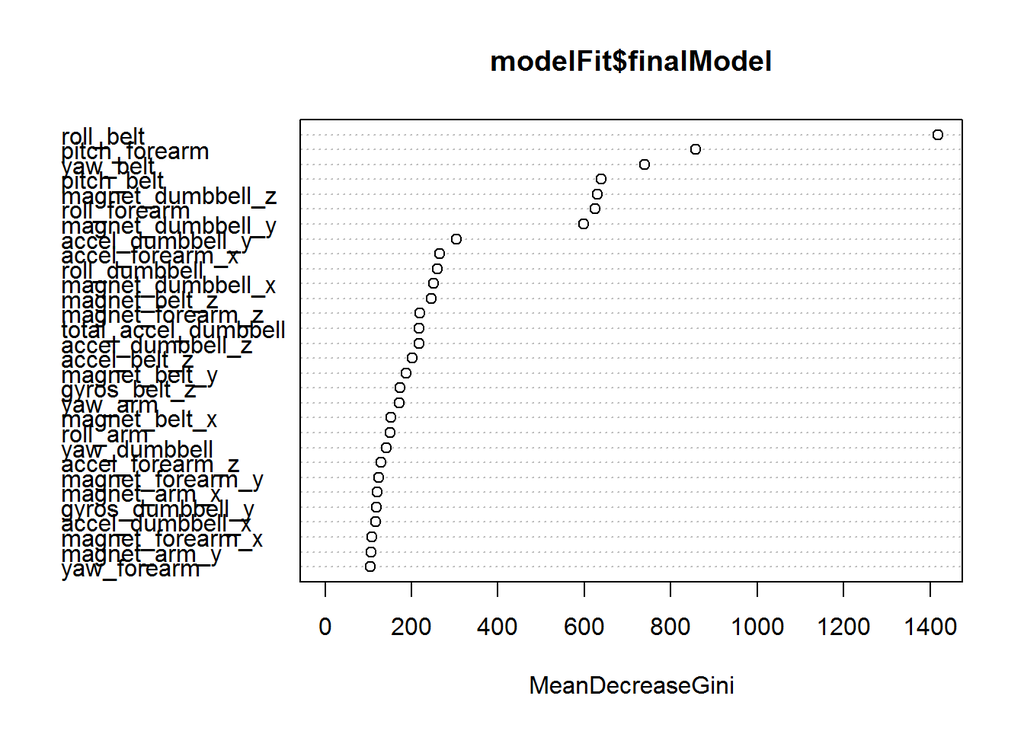

```r
library(randomForest)
modelFit <- readRDS("modelRF.Rds")
varImpPlot(modelFit$finalModel)
```

```r
modelFit$finalModel
```

```
##
## Call:
##  randomForest(x = x, y = y, mtry = param$mtry, proximity = TRUE,      verbose = TRUE, allowParallel = TRUE)
##                Type of random forest: classification
##                      Number of trees: 500
## No. of variables tried at each split: 27
##
##         OOB estimate of  error rate: 0.71%
## Confusion matrix:
##      A    B    C    D    E class.error
## A 3898    5    2    0    1 0.002048131
## B   17 2632    9    0    0 0.009781791
## C    0    9 2379    8    0 0.007095159
## D    0    0   29 2220    3 0.014209591
## E    0    1    5    8 2511 0.005544554
```

The estimated error rate is 0.71%.

### 3) Cross Validation and Out Of Sample Error Rate

Now, we takes the trained model to perform cross validation on the testing dataset split from the 30% of trainSet.

```r
prediction <- predict(modelFit, newdata=testing)
confusionMatrix(prediction, testing$classe)
```

```
## Confusion Matrix and Statistics
##
##           Reference
## Prediction    A    B    C    D    E
##          A 1674    6    0    0    0
##          B    0 1130    9    1    0
##          C    0    3 1013   10    1
##          D    0    0    4  952    3
##          E    0    0    0    1 1078
##
## Overall Statistics
##
##                Accuracy : 0.9935
##                  95% CI : (0.9911, 0.9954)
##     No Information Rate : 0.2845
##     P-Value [Acc > NIR] : < 2.2e-16
##
##                   Kappa : 0.9918
##  Mcnemar's Test P-Value : NA
##
## Statistics by Class:
##
##                      Class: A Class: B Class: C Class: D Class: E
## Sensitivity            1.0000   0.9921   0.9873   0.9876   0.9963
## Specificity            0.9986   0.9979   0.9971   0.9986   0.9998
## Pos Pred Value         0.9964   0.9912   0.9864   0.9927   0.9991
## Neg Pred Value         1.0000   0.9981   0.9973   0.9976   0.9992
## Prevalence             0.2845   0.1935   0.1743   0.1638   0.1839
## Detection Rate         0.2845   0.1920   0.1721   0.1618   0.1832
## Detection Prevalence   0.2855   0.1937   0.1745   0.1630   0.1833
## Balanced Accuracy      0.9993   0.9950   0.9922   0.9931   0.9980
```

The prediction result on the testing dataset show the trained model **accuracy is 99.35%** which is pretty high, as expected by using Random Forest. The **out of sample error** is 100%-99.35% = 0.65%

### 4) Prediction to 20 Test Cases in Quiz

```r
predict20 <- predict(modelFit, newdata=testSet)
predict20
```

```
##  [1] B A B A A E D B A A B C B A E E A B B B
## Levels: A B C D E
```

The final predictions for the 20 test cases in the qiuz are:  
**B, A, B, A, A, E, D, B, A, A, B, C, B, A, E, E, A, B, B, B**